# Inference for Categorical Variables

b06208001 龔泓愷

2018年12月21日

## Q412

1. Row percentages measure the percentage of students feeling right, overweight or underweight about their weight for each gender(men & women) separately.
2. Here is the table of row percentages:

```r
category <- c('Right', 'Overweight', 'Underweight', 'Total')
gender <- c('Female', 'Male', 'Total')
female <- c(87/129, 39/129, 3/129, 129/129)
male <- c(64/83, 3/83, 16/83, 83/83)
total <- c(151/212, 42/212, 19/212, 212/212)

data <- c(female, male, total)

table <- matrix(data, byrow = T, nrow = 3)
colnames(table) <- category
rownames(table) <- gender
table
```

```
##            Right Overweight Underweight Total
## Female 0.6744186 0.30232558  0.02325581     1
## Male   0.7710843 0.03614458  0.19277108     1
## Total  0.7122642 0.19811321  0.08962264     1
```

3. Here is a bar plot of the row percentage:

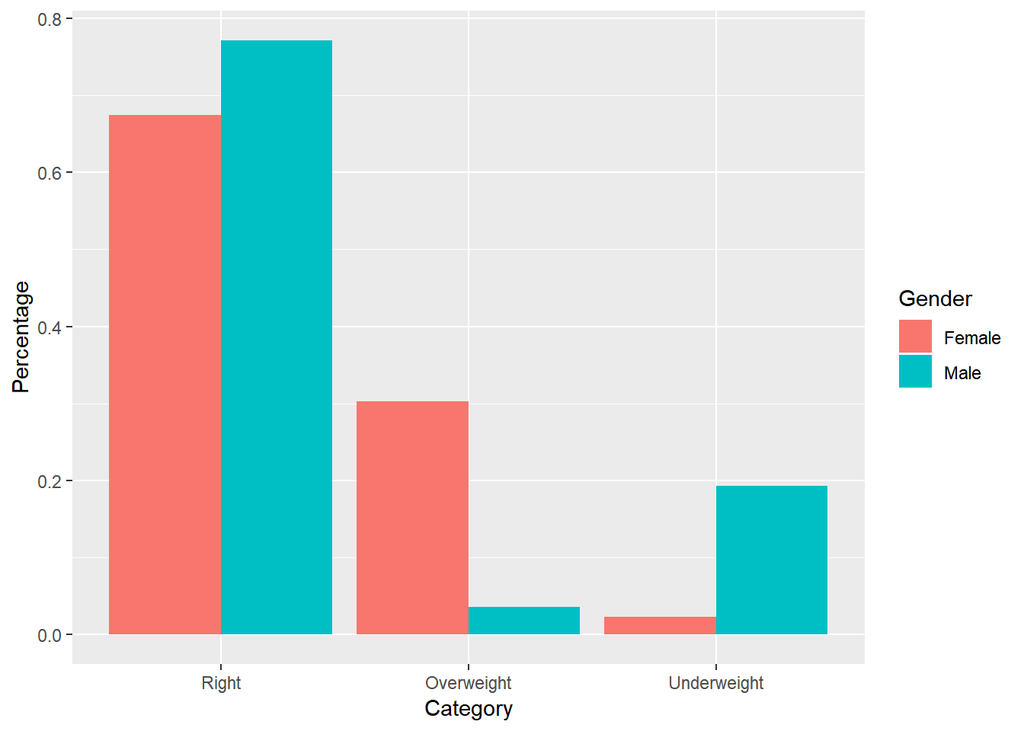

```r
library(ggplot2)
Percentage <- c(female[1:3], male[1:3])
Category <- factor(rep(c('Right', 'Overweight', 'Underweight'), 2),
                   ordered = T, levels = c('Right', 'Overweight', 'Underweight'))
Gender <- c(rep('Female', 3), rep('Male', 3))
data <- data.frame(Percentage, Category, Gender)
ggplot(data, aes(x = Category, y = Percentage, fill = Gender)) +
  geom_col(position = 'dodge')
```

4. Approximately the same percentage feels their weight is about right,  
   More women think that they are overweight and  
   more men think that they are underweight.
5. Students whose ages are probably between 18 ~ 22 (college ages).  
   Because this was a class survey and the statistic students responded to the questions.

## Q426

1. For short, the risk of having been bullied is 45.65217%.  
   For not short, the risk of having been bullied is 25.64103%.

```r
short = 92; short.bullied = 42; notshort = 117; notshort.bullied = 30

risk.short = short.bullied/short; risk.short
```

```
## [1] 0.4565217
```

```r
risk.notshort = notshort.bullied/notshort; risk.notshort
```

```
## [1] 0.2564103
```

2. 1.780435  
   The risk of short being bullied is 1.780435 times the risk for not short.

```r
relative = risk.short/risk.notshort; relative
```

```
## [1] 1.780435
```

3. 78.04348%  
   The interpretation of this percent increase in risk is that short students have a risk of being bullied is 78.04348% higher than the risk of not short students.

```r
risk.increased = relative - 1; risk.increased
```

```
## [1] 0.7804348
```

4. 2.436  
   The odds of being bullied for short are 2.436 times the odds of not short.

```r
short.unbullied = short - short.bullied; short.unbullied
```

```
## [1] 50
```

```r
notshort.unbullied = notshort - notshort.bullied; notshort.unbullied
```

```
## [1] 87
```

```r
odds.short = short.bullied/short.unbullied; odds.short
```

```
## [1] 0.84
```

```r
odds.notshort = notshort.bullied/notshort.unbullied; odds.notshort
```

```
## [1] 0.3448276
```

```r
odds.ratio = odds.short/odds.notshort; odds.ratio
```

```
## [1] 2.436
```

## Q436

1. New Treatment

```r
AS = 5/100; AN = 100/1000
AS > AN
```

```
## [1] FALSE
```

2. New Treatment

```r
BS = 500/1000; BN = 95/100
BS > BN
```

```
## [1] FALSE
```

3. Standard Treatment

```r
outcome = c('Survive', 'Die', 'Total')
treatment = c('Standard', 'New', 'Total')
Standard = c(5+500, 95+500, 100+1000)
New = c(100+95, 900+5, 100+1000)
Total = c(Standard[1]+New[1], Standard[2]+New[2], Standard[3]+New[3])

data <- c(Standard, New, Total)
table = matrix(data, byrow = T, nrow = 3)
colnames(table) <- outcome
rownames(table) <- treatment
table
```

```
##          Survive  Die Total
## Standard     505  595  1100
## New          195  905  1100
## Total        700 1500  2200
```

```r
TS = (5+500)/(100+1000); TN = (100+95)/(1000+100)
TS > TN
```

```
## [1] TRUE
```

4. Simpson’s Paradox.  
   When we considered subgroups, the relationship between treatment and outcome reversed.

## Q1518

1. **Step1**  
   H0：Smoking habits and Marital status are not related.  
   H1：Smoking habits and Marrital status are related.
2. **Step2**  
   Conditions for Chi-Square test are met  
   since 3/4 expected counts are 5+ and no expected counts are < 1.

```r
status <- c('Separated', 'Not_Separated', 'Total')
Smoking <- c('Neither_smoked', 'One_smoked', 'Both_smoked', 'Total')
Neither_smoked = c(41, 931, 972)
One_smoked = c(41, 290, 331)
Both_smoked = c(32, 163, 195)
Total = c(114, 1384, 1498)

data <- c(Neither_smoked, One_smoked, Both_smoked, Total)
table = matrix(data, byrow = T, nrow = 4)
colnames(table) <- status
rownames(table) <- Smoking
table
```

```
##                Separated Not_Separated Total
## Neither_smoked        41           931   972
## One_smoked            41           290   331
## Both_smoked           32           163   195
## Total                114          1384  1498
```

```r
#Calculate Expected Counts
table_expected = table
for (i in 1:3) {
  table_expected[i,1] = table[4,1]*table[i,3]/table[4,3]
  table_expected[i,2] = table[4,2]*table[i,3]/table[4,3]
}
table_expected
```

```
##                Separated Not_Separated Total
## Neither_smoked  73.97063      898.0294   972
## One_smoked      25.18959      305.8104   331
## Both_smoked     14.83979      180.1602   195
## Total          114.00000     1384.0000  1498
```

```r
#Calculate chi-square statistics
chisq = 0
for (i in 1:3) {
  for(j in 1:2) {
    chisq = chisq + (table[i,j] - table_expected[i,j])^2/table_expected[i,j]
  }
}
chisq
```

```
## [1] 48.12525
```

**Step3**

```r
df = (3-1)*(2-1)
p_value = pchisq(chisq, df = df, lower.tail = F);p_value
```

```
## [1] 3.545959e-11
```

**Step4**

```r
p_value < 0.05
```

```
## [1] TRUE
```

Since p_value is less than significance level(0.05),  
The sample shows statistically significant and we can reject the null hypthesis in favor of the alternative hypothesis.

**Step5**  
The sample data shows enough evidence to reject null hypothesis.  
In conclusion, we can say that there is a relationship between smoking habit and marital status in the population of all Austrailian couples.

## Q1526

```r
Frequent = c('Most times/Always', 'Rarely/Never', 'Total')
Gender = c('Female', 'Male', 'Total')
Female = c(964, 97, 1061)
Male = c(924, 254, 1178)
Total = c(1888, 351, 2239)

data <- c(Female, Male, Total)
table = matrix(data, byrow = T, nrow = 3)
colnames(table) <- Frequent
rownames(table) <- Gender
table
```

```
##        Most times/Always Rarely/Never Total
## Female               964           97  1061
## Male                 924          254  1178
## Total               1888          351  2239
```

```r
chisq = (table[3,3]*(table[1,1]*table[2,2] - table[1,2]*table[2,1])^2)/(table[1,3]*table[2,3]*table[3,1]*table[3,2])
chisq
```

```
## [1] 65.1365
```

```r
(2-1)*(2-1)
```

```
## [1] 1
```

```r
p_value = pchisq(chisq, df = 1, lower.tail = F);p_value
```

```
## [1] 6.988548e-16
```

```r
p_value < 0.05
```

```
## [1] TRUE
```

Since p_value is less than significance level(0.05),  
The sample shows statistically significant and we can reject the null hypthesis in favor of the alternative hypothesis.  
In conclusion, we can say that there is a relationship between the sex of a student and the freuency of wearing a seatbelt in the population of all American students.

## Q1540

**Step1**  
H0：The colors are equally preferred.  
H1：The colors are not equally preferred.

**Step2**  
Conditions for Chi-Square test are met  
since 3/4 expected counts are 5+ and no expected counts are < 1.

```r
counts <- c(59, 27, 25)
expected <- c(37, 37, 37)#equally preferred
chisq = 0
for (i in 1:3){
  chisq = chisq + (counts[i] - expected[i])^2/expected[i]
}
chisq
```

```
## [1] 19.67568
```

**Step3**

```r
#df：goodness of fit df k - 1
p_value = pchisq(chisq, df = 3 - 1, lower.tail = F);p_value
```

```
## [1] 5.339263e-05
```

**Step4**

```r
p_value < 0.05
```

```
## [1] TRUE
```

Since p_value is less than significance level(0.05),  
The sample shows statistically significant and we can reject the null hypthesis in favor of the alternative hypothesis.

**Step5**  
In conclusion, we can say that the probabilities of selecting the color for a new car are not the same in the population of all statistics students.

## R Function Practice

### **Customized Chi-Square Function**

```r
MyChiSq <- function(table) {
  # row total, column total, total
  total_row = c()
  for (i in 1:nrow(table)){
    total_row[i] = sum(table[i,])
  }
  total_col = c()
  for (i in 1:ncol(table)){
    total_col[i] = sum(table[,i])
  }
  total = sum(table)


  # generate an expected table
  table_expected = table
  for (i in 1:nrow(table)) {
    for ( j in 1:ncol(table)) {
      table_expected[i,j] = total_row[i]*total_col[j]/total
    }
  }

  # calculate each (observed-expected)^2/expected and Chi-square statistics
  chisq = 0
  for (i in 1:nrow(table)) {
    for ( j in 1:ncol(table)) {
      chisq = chisq + (table[i,j] - table_expected[i,j])^2/table_expected[i,j]
    }
  }

  # calculate p-value
  df = (nrow(table) - 1)*(ncol(table) - 1)
  p_value = pchisq(chisq, df = df, lower.tail = F)

  # results of the function
  results = list(X.squared = chisq, df = df, p.value = p_value)
  return(results)

}
data = read.csv("heartatk.csv")
table = xtabs(~ SEX + DIED, data = data) # generate a 2x2 table
MyChiSq(table)
```

```
## $X.squared
## [1] 148.4641
##
## $df
## [1] 1
##
## $p.value
## [1] 3.755555e-34
```

```r
chisq.test(table, correct = F)
```

```
##
##  Pearson's Chi-squared test
##
## data:  table
## X-squared = 148.46, df = 1, p-value < 2.2e-16
```

可以看到自訂函數與內建`chisq.test`結果相符。

### **Testing Binomial Distribution**

**Step1**  
H0：符合二項分布  
H1：不符合二項分布

**Step2**

```r
x = c(0,1,2,3,4,5,6,7)#每周下雨天數

#observed values
obs = c(5,13,26,19,20,7,0,0)#周次數
n = sum(obs)
pp = sum(x*obs)/(n*7)

#expected values
exp = c()
for (i in 1:length(obs)) {
  exp[i] = dbinom(x = x[i], prob = pp, size = 7) * n #每周下雨x天，每天下雨機率pp，每周7天(有下雨/沒下雨)
}
#combining 6,7,8 rows
tbl = data.frame(x, obs, exp)
tbl.678 = tbl[6,] + tbl[7,] + tbl[8,] #add up 6,7,8 rows
tbl = tbl[-c(6,7,8),] #remove 6,7,8 rows
tbl = rbind(tbl, tbl.678) #add the combined row
tbl
```

```
##    x obs       exp
## 1  0   5  3.308312
## 2  1  13 13.965624
## 3  2  26 25.266053
## 4  3  19 25.394633
## 5  4  20 15.314321
## 6 18   7  6.751056
```

滿足卡方檢定的條件。

```r
#calculate the chi-square statistic
chisq = sum((tbl$obs-tbl$exp)^2/tbl$exp); chisq
```

```
## [1] 4.006201
```

**Step3**

```r
df = nrow(tbl)-1-1 #k-1-r
p_value = pchisq(chisq, df = df, lower.tail = F);p_value
```

```
## [1] 0.4051673
```

**Step4**

```r
alpha = 0.05
p_value < alpha
```

```
## [1] FALSE
```

p_value大於顯著水準，我們沒有足夠的證據推翻H0。

**Step5**  
既然我們無法拒絕虛無假說，我們就不能下【不符合二項分布】的結論，因為我們不能拒絕【符合二項分布】的可能性。

### **Testing Normal Distribution**

**Step1**  
H0：符合常態分佈  
H1：不符合常態分布

**Step2**

```r
pm2.5 = c(18.8, 14.6, 14.0, 15.8, 12.4, 13.2, 16.1, 13.8, 16.2,
          16.1, 17.8, 18.7, 15.8, 13.3, 13.6, 16.4, 13.8, 16.6,
          15.3, 19.0, 18.4, 15.0, 18.8, 18.1, 17.3, 16.3, 17.5,
          18.1, 14.2, 18.0, 13.0, 13.3, 12.4, 16.6, 14.1, 20.6,
          16.8, 13.3, 18.2, 16.9)

#defining thresholds to categorize continuous data
mean = mean(pm2.5)
sd = sd(pm2.5)

n = length(pm2.5)

thres = c(mean-3*sd, mean-2*sd, mean-sd, mean, mean+sd, mean+2*sd, mean+3*sd)

#observed values (continuous --> discrete)
obs = rep(0, length = 8)

for (i in 1:length(pm2.5)) {
  if (pm2.5[i] < thres[1]) {
    obs[1] = obs[1] + 1
  } else if (thres[1] <= pm2.5[i] && pm2.5[i] < thres[2]) {
    obs[2] = obs[2] + 1
  } else if (thres[2] <= pm2.5[i] && pm2.5[i] < thres[3]) {
    obs[3] = obs[3] + 1
  } else if (thres[3] <= pm2.5[i] && pm2.5[i] < thres[4]) {
    obs[4] = obs[4] + 1
  } else if (thres[4] <= pm2.5[i] && pm2.5[i] < thres[5]) {
    obs[5] = obs[5] + 1
  } else if (thres[5] <= pm2.5[i] && pm2.5[i] < thres[6]) {
    obs[6] = obs[6] + 1
  } else if (thres[6] <= pm2.5[i] && pm2.5[i] < thres[7]) {
    obs[7] = obs[7] + 1
  } else {
    obs[8] = obs[8] + 1
  }
}

#expected values
cumu.p = c(pnorm(thres[1], mean = mean, sd = sd),
           pnorm(thres[2], mean = mean, sd = sd) - pnorm(thres[1], mean = mean, sd = sd),
           pnorm(thres[3], mean = mean, sd = sd) - pnorm(thres[2], mean = mean, sd = sd),
           pnorm(thres[4], mean = mean, sd = sd) - pnorm(thres[3], mean = mean, sd = sd),
           pnorm(thres[5], mean = mean, sd = sd) - pnorm(thres[4], mean = mean, sd = sd),
           pnorm(thres[6], mean = mean, sd = sd) - pnorm(thres[5], mean = mean, sd = sd),
           pnorm(thres[7], mean = mean, sd = sd) - pnorm(thres[6], mean = mean, sd = sd),
           pnorm(thres[7], mean = mean, sd = sd, lower.tail = F)
           )

exp = cumu.p * n

cate = c("< m-3d ~ m-d", "m-d ~ m", "m ~ m+d", "m+d ~ > m+3d")

tbl = data.frame(obs, exp)

tbl.123 = tbl[1,] + tbl[2,] + tbl[3,] #add up 1,2,3 rows
tbl.678 = tbl[6,] + tbl[7,] + tbl[8,] #add up 6,7,8 rows
tbl = tbl[-c(1,2,3,6,7,8),] #remove 1,2,3,6,7,8 rows
tbl = rbind(tbl.123, tbl) #add the combined row
tbl = rbind(tbl, tbl.678) #add the combined row
rownames(tbl) = cate
tbl
```

```
##              obs      exp
## < m-3d ~ m-d  10  6.34621
## m-d ~ m        8 13.65379
## m ~ m+d       15 13.65379
## m+d ~ > m+3d   7  6.34621
```

滿足卡方檢定的條件。

```r
#calculate the chi-square statistic
chisq = sum((tbl$obs-tbl$exp)^2/tbl$exp); chisq
```

```
## [1] 4.644864
```

**Step3**

```r
df = nrow(tbl)-1-2  # k-1-r
p_value = pchisq(chisq, df = df, lower.tail = F);p_value
```

```
## [1] 0.0311466
```

**Step4**

```r
alpha = 0.05
p_value < alpha
```

```
## [1] TRUE
```

p_value小於顯著水準，我們有足夠的證據推翻H0。

**Step5**  
我們拒絕虛無假說接受對立假說，因此我們能下【不符合常態分布】的結論。